# Matplotlib - Complete Guide

Resources - [Github](https://github.com/PacktPublishing/Matplotlib-3.0-Cookbook)

## Chapter 1 - Anatomy of Matplotlib

### 1.1 Architecture of Matplotlib

Matplotlib has a three-layer architecture: backend, artist, and scripting, organized logically as a stack.

#### Backend Layer

This is the bottom-most layer where the graphs are displayed on to an output device.There are two types of backends:

- **User interface backends**| (interactive backends)
- **Hard-copy backends** to make image files(non-interactive backends)

#### Artist Layer

This is the middle layer of the stack. Matplotlib uses the artist object to draw various elements of the graph.

#### Scripting Layer (pyplot API)

This is the topmost layer of the stack. This layer provides a simple interface for creating graphs.

### 1.2 Elements of a figure

[figure not shown]

1. **Axes** - is a sub-section of the figure, where a graph is plotted. axes has a title, an x-label and a y-label. A figure can have many such axes
2. **Axis** - number lines representing the scale of the graphs being plotted.(Axis is an element of axes)
3. **Label** - This is the name given to various elements of the figure, for example, x axis label, y axis label, graph label
4. **Legend**
5. **Title**
6. **Ticklabels**
7. **Spines** - boundaries of the figure
8. **Grid**

Interactive Mode - the graph display gets updated after each statement

- `matplotlib.pyplot.ion()` to set the interactive mode ON
- `matplotlib.pyplot.ioff()` to switch OFF the interactive mode
- `matplotlib.is_interactive()` to check whether the interactive mode is ON (True) or OFF (False)

```
Interactive Mode:  True
```

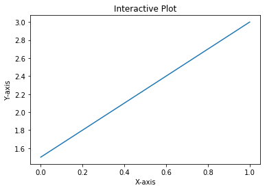

```python
# set screen output as the backend
%matplotlib inline

import matplotlib as mpl
import matplotlib.pyplot as plt

# Turn on Interactive Mode - interactively adds elements on shell;
# write in separate shells to run in jupyter notebook
plt.ion()
print ('Interactive Mode: ',mpl.is_interactive())

plt.plot([1.5, 3.0])

# Add labels and title
plt.title("Interactive Plot") #Prints the title on top of graph
plt.xlabel("X-axis")         # Prints X axis label as "X-axis"
plt.ylabel("Y-axis")         # Prints Y axis label as "Y-axis"
```

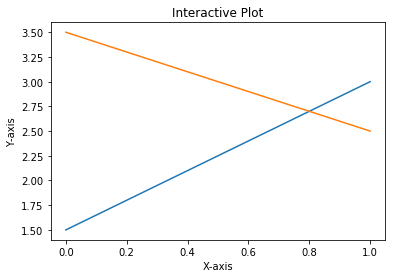

```python
plt.plot([1.5, 3.0])
plt.plot([3.5, 2.5])
plt.title("Interactive Plot")
plt.xlabel("X-axis")
plt.ylabel("Y-axis")
```

### 1.3 Changing and resetting default environment variables

Matplotlib uses the matplotlibrc file to store default values for various environment and figure parameters used across matplotlib functionality.

```python
# Get the location of matplotlibrc file
import matplotlib
matplotlib.matplotlib_fname()
```

```
'D:\\PythonPrograms\\Anaconda3\\lib\\site-packages\\matplotlib\\mpl-data\\matplotlibrc'
```

```python
matplotlib.rc('lines', linewidth=4, linestyle='-', marker='*')
matplotlib.rcParams['lines.markersize'] = 20
matplotlib.rcParams['font.size'] = '15.0'
```

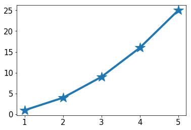

```python
import numpy as np
arr = np.array([[ 1., 1.], [ 2., 4.], [ 3., 9.], [ 4., 16.], [ 5., 25.]])
x = arr[:,0]
y = arr[:,1]
plt.plot(x, y)
```

Restoring Default values to RC Params

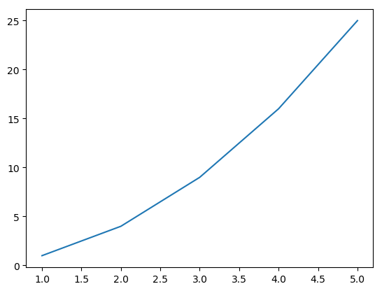

```python
matplotlib.rcdefaults()
plt.plot(x,y)
```

## 2. Basic Plots

### 2.1 Line Plot

```python
import pandas as pd
stock = pd.read_csv('https://raw.githubusercontent.com/PacktPublishing/Matplotlib-3.0-Cookbook/master/Chapter02/GOOG.csv', header = None)
stock.columns = ['date','price']
stock.head()
```

|  | date | price |
| --- | --- | --- |
| 0 | 15-05-2018 | 1079.229980 |
| 1 | 16-05-2018 | 1081.770020 |
| 2 | 17-05-2018 | 1078.589966 |
| 3 | 18-05-2018 | 1066.359985 |
| 4 | 21-05-2018 | 1079.579956 |

```python
stock['date'] = pd.to_datetime(stock.date, format='%d-%m-%Y')
stock.set_index('date', inplace = True)
```

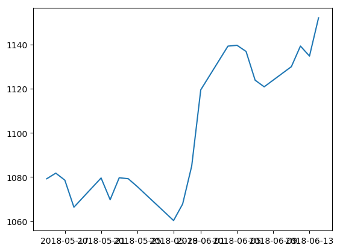

```python
plt.plot(stock['price'])
```

### 2.2 Bar Plot

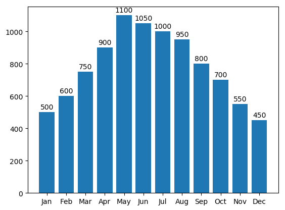

```python
import matplotlib.pyplot as plt
import numpy as np
import calendar

month_num = [1, 2, 3, 4, 5, 6, 7, 8, 9, 10, 11, 12]
units_sold = [500, 600, 750, 900, 1100, 1050, 1000, 950, 800, 700, 550, 450]

fig, ax = plt.subplots()
plt.xticks(month_num, calendar.month_abbr[1:13], rotation = 0)
plot = ax.bar(month_num, units_sold)
for rect in plot:
    ax.text(rect.get_x() + rect.get_width()/2, rect.get_height()+10,str(int(rect.get_height())), ha = 'center', va = 'bottom')
```

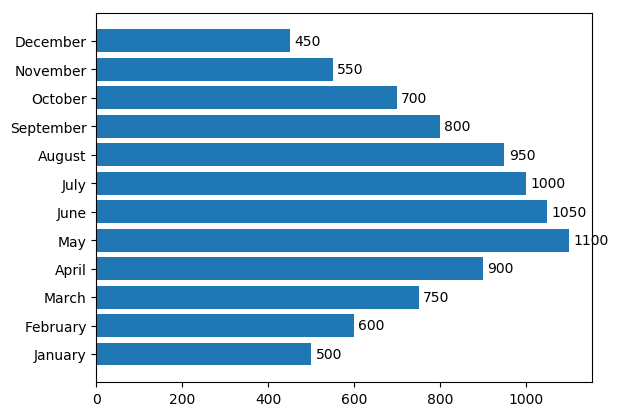

```python
plot2 = plt.barh(month_num, units_sold)
plt.yticks(month_num, calendar.month_name[1:13], rotation=0)
for rect in plot2:
    plt.text(rect.get_width() + 10, rect.get_y()+rect.get_height()/2, str(int(rect.get_width())),  va = 'center')
plt.show()
```

## 2.3 Scatter Plot

```python
age_weight = pd.read_excel('https://github.com/PacktPublishing/Matplotlib-3.0-Cookbook/blob/master/Chapter02/scatter_ex.xlsx?raw=true')
```

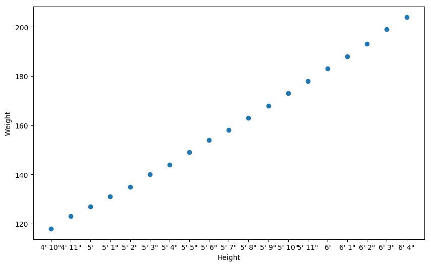

```python
plt.figure(figsize=(10,6))
x = age_weight['height']
y = age_weight['weight']
plt.scatter(x, y)
plt.xlabel('Height')
plt.ylabel('Weight')
plt.show()
```

```python
iris = pd.read_csv('https://raw.githubusercontent.com/PacktPublishing/Matplotlib-3.0-Cookbook/master/Chapter02/iris_dataset.csv')
iris.head()
```

|  | sepal_length | sepal_width | petal_length | petal_width | species |
| --- | --- | --- | --- | --- | --- |
| 0 | 5.1 | 3.5 | 1.4 | 0.2 | setosa |
| 1 | 4.9 | 3.0 | 1.4 | 0.2 | setosa |
| 2 | 4.7 | 3.2 | 1.3 | 0.2 | setosa |
| 3 | 4.6 | 3.1 | 1.5 | 0.2 | setosa |
| 4 | 5.0 | 3.6 | 1.4 | 0.2 | setosa |

```python
# each class of species is defined with descriptive names, which we will map to numeric codes as 0, 1, or 2
iris['species'] = iris['species'].map({"setosa" : 0, "versicolor" : 1, "virginica" : 2})
```

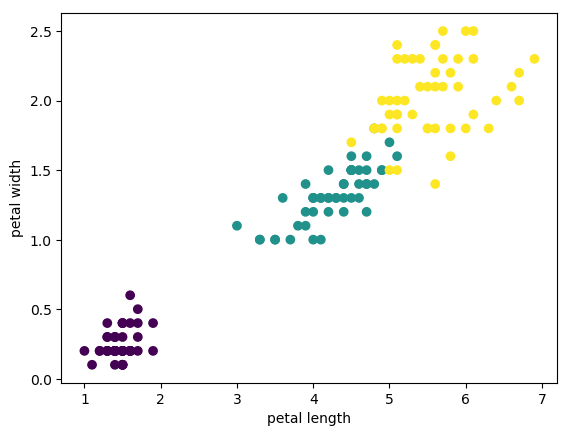

```python
# c does not take non numeric arguments
plt.scatter(iris.petal_length, iris.petal_width, c=iris.species)
plt.xlabel('petal length')
plt.ylabel('petal width')
plt.show()
```

## 2.4 Bubble Plot

It is a manifestation of the scatter plot, where each point on the graph is shown as a bubble. Each of these bubbles can be displayed with a different color, size, and appearance.

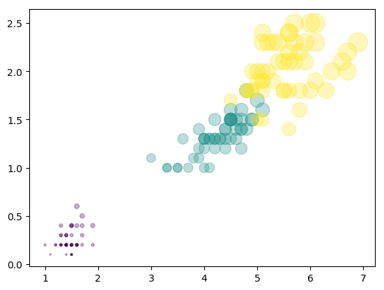

```python
plt.scatter(x = iris.petal_length,
            y = iris.petal_width,
            s = 25*iris.petal_length * iris.petal_width, # specifies the size of the bubble
            c = iris.species, # specifies different classes (clusters) in the data.
            alpha = 0.3) # transparency of the bubble
plt.show()
```

## 2.5 Stacked Plot

A stacked plot represents the area under the line plot, and multiple line plots are stacked one over the other. It is used to provide a visualization of the cumulative effect of multiple variables being plotted on the y axis.

```python
# data
x = np.arange(6)+1
Apr = [5, 7, 6, 8, 7, 9]
May = [0, 4, 3, 7, 8, 9]
June = [6, 7, 4, 5, 6, 8]
labels = ["April", "May", "June"]
```

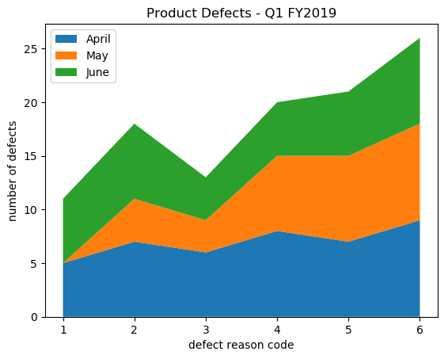

```python
fig, ax = plt.subplots()
ax.stackplot(x, Apr, May, June, labels=labels)
ax.legend(loc=2) # specifies the legend to be plotted in the top left of the graph

plt.xlabel('defect reason code')
plt.ylabel('number of defects')
plt.title('Product Defects - Q1 FY2019')

plt.show()
```

## 2.6 Pie Chart

A pie plot is used to represent the contribution of various categories/groups to the total.

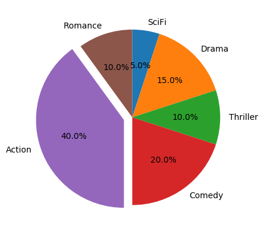

```python
labels = ['SciFi', 'Drama', 'Thriller', 'Comedy', 'Action', 'Romance']
sizes = [5, 15, 10, 20, 40, 10] # Add upto 100%
explode = (0, 0, 0, 0, 0.1, 0) # only "explode" the 5th slice (i.e.'Action')
plt.pie(sizes,
        labels = labels,
        explode = explode,
        autopct = '%1.1f%%',
        counterclock = False,
        startangle = 90)
plt.show()
```

## 2.7 Table Chart

A table chart is a combination of a bar chart and a table, representing the same data. So, it is a combination of pictorial representation along with the corresponding data in a table.

```python
rows = ['2011', '2012', '2013', '2014', '2015']
columns = ('7Ah', '35Ah', '40Ah', '135Ah', '150Ah')
data = [[75, 144, 114, 102, 108],
        [90, 126, 102, 84, 126],
        [96, 114, 75, 105, 135],
        [105, 90, 150, 90, 75],
        [90, 75, 135, 75, 90]]
```

```python
values = np.arange(0, 600, 100)
colors = plt.cm.OrRd(np.linspace(0, 0.5, len(rows)))
index = np.arange(len(columns))
bar_width = 0.5
y_offset = np.zeros(len(columns))
```

```python
y_offset
```

```
array([0., 0., 0., 0., 0.])
```

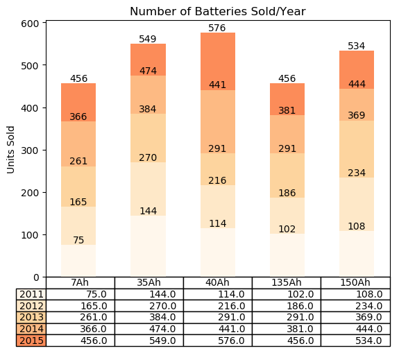

```python
fig, ax = plt.subplots()
cell_text = []
n_rows = len(data)
for row in range(n_rows):
    plot = plt.bar(index, data[row], bar_width, bottom=y_offset,
                   color=colors[row])
    y_offset = y_offset + data[row]
    cell_text.append(['%1.1f' % (x) for x in y_offset])
    i=0
# Each iteration of this for loop, labels each bar with corresponding value for the given year
    for rect in plot:
        height = rect.get_height()
        ax.text(rect.get_x() + rect.get_width()/2, y_offset[i],'%d'
                % int(y_offset[i]),
                ha='center', va='bottom')
        i = i+1
the_table = plt.table(cellText=cell_text, rowLabels=rows,
                rowColours=colors, colLabels=columns, loc='bottom')
plt.ylabel("Units Sold")
plt.xticks([])
plt.title('Number of Batteries Sold/Year')
plt.show()
```

## 2.8 Polar Plot (spider Chart)

The polar plot is a chart plotted on the polar axis, which has coordinates as angle (in degrees) and radius, as opposed to the Cartesian system of x and y coordinates

```python
Depts = ["COGS","IT","Payroll","R & D", "Sales & Marketing"]
rp = [30, 15, 25, 10, 20, 30] # planned expenses
ra = [32, 20, 23, 11, 14, 32] # actual spending

theta = np.linspace(0, 2 * np.pi, len(rp))
```

The pyplot method accepts only radians as input, hence we need to divide 2 x np.pie (which is equivalent to 360 degrees) radians into number of departments equally, to get the angle coordinates for each of the departments

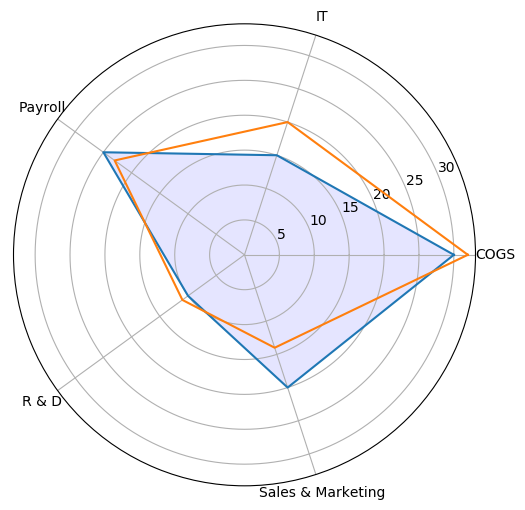

```python
plt.figure(figsize=(10,6))
plt.subplot(polar=True)
(lines,labels) = plt.thetagrids(range(0,360, int(360/len(Depts))), (Depts))
plt.plot(theta, rp)
plt.fill(theta, rp, 'b', alpha=0.1)
plt.plot(theta, ra)
plt.show()
```

## 2.9 Histogram

Continuous variable values are split into the required number of bins and plotted on the x axis, and the count of values that fall in each of the bins is plotted on the y axis. On the y axis, instead of count, we can also plot percentage of total, in which case it represents probability distribution.

```python
import matplotlib.pyplot as plt
import numpy as np
```

```python
grp_exp = np.array([12, 15, 13, 20, 19, 20, 11, 19, 11, 12, 19, 13, 12,
                    10, 6, 19, 3, 1, 1, 0, 4, 4, 6, 5, 3, 7, 12, 7, 9,
                    8, 12, 11, 11, 18, 19, 18, 19, 3, 6, 5, 6, 9, 11,
                    10, 14, 14, 16, 17, 17, 19, 0, 2, 0, 3, 1, 4, 6,
                    6, 8, 7, 7, 6, 7, 11, 11, 10, 11, 10, 13, 13, 15,
                    18, 20, 19, 1, 10, 8, 16, 19, 19, 17, 16, 11, 1,
                    10, 13, 15, 3, 8, 6, 9, 10, 15, 19, 2, 4, 5, 6, 9,
                    11, 10, 9, 10, 9, 15, 16, 18, 13])
```

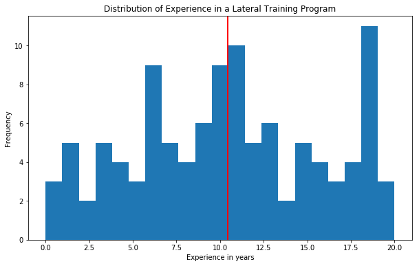

```python
plt.figure(figsize=(10,6))
nbins = 21
n, bins, patches = plt.hist(grp_exp, bins = nbins)
plt.xlabel("Experience in years")
plt.ylabel("Frequency")
plt.title("Distribution of Experience in a Lateral Training Program")
plt.axvline(x=grp_exp.mean(), linewidth=2, color = 'r')
plt.show()
```

- `n` is the list containing the number of items in each bin,
- `bins` is another list specifying starting point of the bin, and
- `patches` is the list of objects for each bin.

### Density Plot

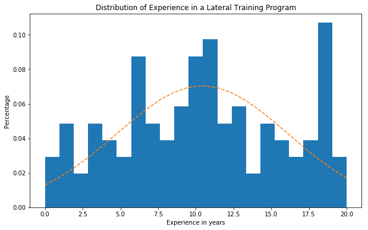

```python
plt.figure(figsize=(10,6))
nbins = 21
n, bins, patches = plt.hist(grp_exp, bins = nbins, density=1)
plt.xlabel("Experience in years")
plt.ylabel("Percentage")
plt.title("Distribution of Experience in a Lateral Training Program")
mu = grp_exp.mean()
sigma = grp_exp.std()
y = ((1 / (np.sqrt(2 * np.pi) * sigma)) * np.exp(-0.5 * (1 / sigma * (bins - mu))**2))
plt.plot(bins, y, '--')
plt.show()
```

## 2.10 Box Plot

It visually shows the first and third quartile, median (mean), and whiskers at 1.5 times the Inter Quartile Range (IQR)—the difference between the third and first quartiles, above which are outliers. The first quartile (the bottom of rectangular box) marks a point below which 25% of the total points fall. The third quartile (the top of rectangular box) marks a point below which 75% of the points fall.

```python
import matplotlib.pyplot as plt
import pandas as pd
```

```python
wine_quality = pd.read_csv('https://raw.githubusercontent.com/PacktPublishing/Matplotlib-3.0-Cookbook/master/Chapter02/winequality.csv', delimiter=';')
wine_quality.head()
```

|  | fixed acidity | volatile acidity | citric acid | residual sugar | chlorides | free sulfur dioxide | total sulfur dioxide | density | pH | sulphates | alcohol | quality |
| --- | --- | --- | --- | --- | --- | --- | --- | --- | --- | --- | --- | --- |
| 0 | 7.4 | 0.70 | 0.00 | 1.9 | 0.076 | 11.0 | 34.0 | 0.9978 | 3.51 | 0.56 | 9.4 | 5 |
| 1 | 7.8 | 0.88 | 0.00 | 2.6 | 0.098 | 25.0 | 67.0 | 0.9968 | 3.20 | 0.68 | 9.8 | 5 |
| 2 | 7.8 | 0.76 | 0.04 | 2.3 | 0.092 | 15.0 | 54.0 | 0.9970 | 3.26 | 0.65 | 9.8 | 5 |
| 3 | 11.2 | 0.28 | 0.56 | 1.9 | 0.075 | 17.0 | 60.0 | 0.9980 | 3.16 | 0.58 | 9.8 | 6 |
| 4 | 7.4 | 0.70 | 0.00 | 1.9 | 0.076 | 11.0 | 34.0 | 0.9978 | 3.51 | 0.56 | 9.4 | 5 |

```python
data = [wine_quality['alcohol'], wine_quality['fixed acidity'],
        wine_quality['quality']]
```

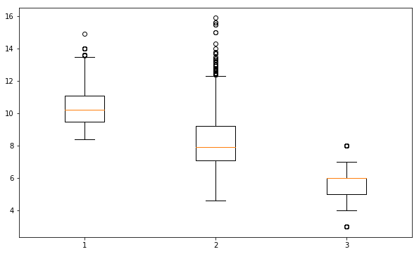

```python
plt.figure(figsize=(10,6))
plt.boxplot(data)
plt.show()
```

- The `data` argument can be a list of one or more attributes.
- The yellow line in each box represents the median value of the attribute by default
- The bottom line of the box is at the first quartile, and the upper line of the box is at the third quartile of the data.

### Horizontal Box plot

- vert=False argument, you can plot the box plots horizontally
- by specifying the `showfliers = False` argument, you can suppress the outliers, so it plots only up to the whiskers on both sides.

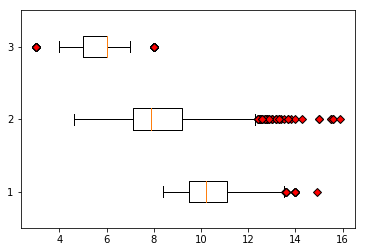

```python
plt.boxplot(data, vert=False, flierprops=dict(markerfacecolor='r', marker='D'))
plt.show()
```

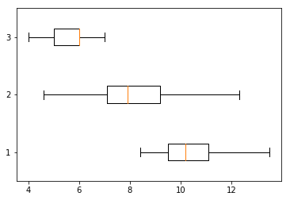

```python
plt.boxplot(data, vert=False, showfliers=False)
plt.show()
```

## 2.11 Violin Plot

The violin plot is a combination of histogram and box plot. It gives information on the complete distribution of data, along with mean/median, min, and max values.

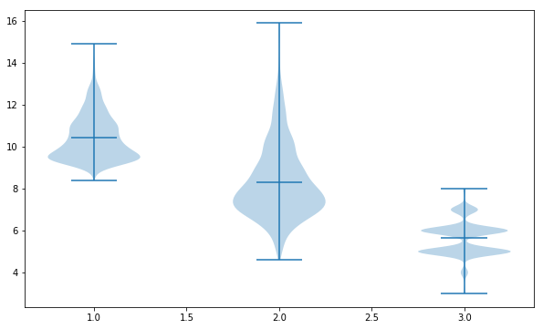

```python
data = [wine_quality['alcohol'], wine_quality['fixed acidity'], wine_quality['quality']]
plt.figure(figsize = (10,6))
plt.violinplot(data, showmeans=True)
plt.show()
```

- The bottom whisker is the minimum value,
- the top whisker is the maximum value, and
- the horizontal line is at the mean value.
- `showmedian = True`, we can have a horizontal line representing the median of the data instead of the mean

## 2.11 Reading and Displaying Images

Matplotlib.pyplot has features that enable us to read .jpeg and .png images and covert them to pixel format to display as images.

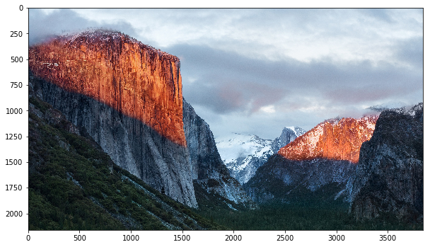

```python
import matplotlib.pyplot as plt
plt.figure(figsize = (10,6))
image = plt.imread('C:/Users/sumit kant/Pictures/Wallpapers/apple_mac_os_x_el_capitan-3840x2160.jpg')
plt.imshow(image)
plt.show()
```

```python
print("Dimensions of the image: ", image.shape)
```

```
Dimensions of the image:  (2160, 3840, 3)
```

## 2.12 Heatmap

```python
import matplotlib.pyplot as plt
import pandas as pd
wine_quality = pd.read_csv('https://raw.githubusercontent.com/PacktPublishing/Matplotlib-3.0-Cookbook/master/Chapter02/winequality.csv', delimiter=';')
wine_quality.head(3)
```

|  | fixed acidity | volatile acidity | citric acid | residual sugar | chlorides | free sulfur dioxide | total sulfur dioxide | density | pH | sulphates | alcohol | quality |
| --- | --- | --- | --- | --- | --- | --- | --- | --- | --- | --- | --- | --- |
| 0 | 7.4 | 0.70 | 0.00 | 1.9 | 0.076 | 11.0 | 34.0 | 0.9978 | 3.51 | 0.56 | 9.4 | 5 |
| 1 | 7.8 | 0.88 | 0.00 | 2.6 | 0.098 | 25.0 | 67.0 | 0.9968 | 3.20 | 0.68 | 9.8 | 5 |
| 2 | 7.8 | 0.76 | 0.04 | 2.3 | 0.092 | 15.0 | 54.0 | 0.9970 | 3.26 | 0.65 | 9.8 | 5 |

```python
corr = wine_quality.corr()
```

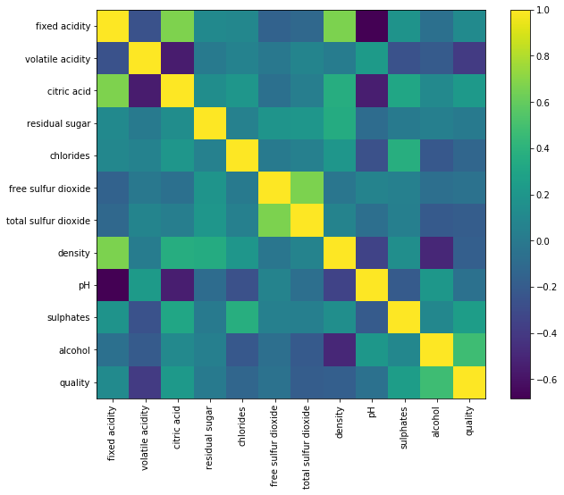

```python
plt.figure(figsize = (10,8))
plt.imshow(corr, cmap = 'viridis')
plt.colorbar()
plt.xticks(range(len(corr)), corr.columns, rotation = 90)
plt.yticks(range(len(corr)), corr.columns)
plt.show()
```

## 2.13 Hinton Diagram

- for visualizing weight matrics in deep learning applications

```python
import numpy as np
import matplotlib.pyplot as plt
import pandas as pd
```

```python
matrix = np.asarray((pd.read_excel('https://github.com/PacktPublishing/Matplotlib-3.0-Cookbook/blob/master/Chapter02/weight_matrix.xlsx?raw=true')))
```

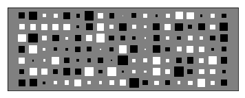

```python
fig, ax = plt.subplots()

ax.patch.set_facecolor('gray')
ax.set_aspect('equal','box')
ax.xaxis.set_major_locator(plt.NullLocator()) #ets the x axis ticks to nulls
ax.yaxis.set_major_locator(plt.NullLocator())

max_weight = 2 ** np.ceil(np.log(np.abs(matrix).max()) / np.log(2))

for (x, y), w in np.ndenumerate(matrix):
    color = 'white' if w > 0 else 'black'
    size = np.sqrt(np.abs(w) / max_weight)
    rect = plt.Rectangle([x - size / 2, y - size / 2], size, size, facecolor=color, edgecolor=color)
    ax.add_patch(rect)
ax.autoscale_view() #arranges all the boxes neatly and plots the Hinton diagram.

plt.show()
```

## 2.14 Contour Plot

typically used to display how the error varies with varying coefficients that are being optimized in a machine learning algorithm

```python
import matplotlib.pyplot as plt
import pandas as pd
import numpy as np
from matplotlib import cm
```

```python
Loss = pd.read_excel('https://github.com/PacktPublishing/Matplotlib-3.0-Cookbook/blob/master/Chapter02/Loss.xlsx?raw=true')
theta0_vals = np.linspace(-10, 10, 100)
theta1_vals = np.linspace(-1, 4, 100)
```

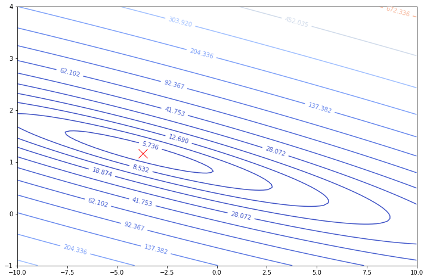

```python
fig = plt.figure(figsize=(12,8))
X, Y = np.meshgrid(theta0_vals, theta1_vals)
CS = plt.contour(X, Y, Loss, np.logspace(-2,3,30),
                 cmap=cm.coolwarm)
plt.clabel(CS, inline=1, fontsize=10)

# Plot the minimum point(Theta at Minimum cost)
plt.plot(theta0_vals[Loss.min(axis= 0).idxmin()],
         theta1_vals[Loss.min(axis= 1).idxmin()], 'rx', markersize=15, linewidth=2)

plt.show()
```

## 2.15 Triangulations

Triangulations are used to plot geographical maps, which help with understanding the relative distance between various points. The longitude and latitude values are used as x, y coordinates to plot the points.

```python
import numpy as np
import matplotlib.pyplot as plt
import matplotlib.tri as tri
```

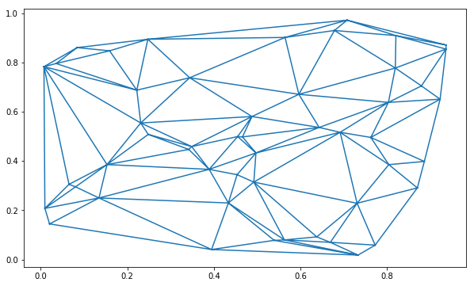

```python
data = np.random.rand(50, 2)
triangles = tri.Triangulation(data[:,0], data[:,1]) #creates triangles automatically
plt.figure(figsize=(10,6))
plt.triplot(triangles)
plt.show()
```

```python
xy = np.array([[-0.101, 0.872], [-0.080, 0.883], [-0.069, 0.888],
               [-0.054, 0.890], [-0.045, 0.897], [-0.057, 0.895],
               [-0.073, 0.900], [-0.087, 0.898],
               [-0.090, 0.904], [-0.069, 0.907]])
```

```python
x = np.degrees(xy[:, 0])
y = np.degrees(xy[:, 1])
```

```python
triangles = np.array([[1, 2, 3], [3, 4, 5], [4, 5, 6], [2, 5, 6],
                      [6, 7, 8], [6, 8, 9], [0, 1, 7]])
```

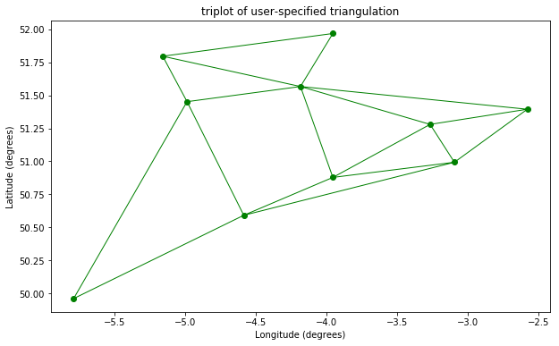

```python
plt.figure(figsize=(10,6))
plt.title('triplot of user-specified triangulation')
plt.xlabel('Longitude (degrees)')
plt.ylabel('Latitude (degrees)')
plt.triplot(x, y, triangles, 'go-', lw=1.0)
plt.show()
```

## 2.16 Stream Plot

known as streamline plots are used to visualize vector fields. They are mostly used in the engineering and scientific communities

```python
import numpy as np
import matplotlib.pyplot as plt
import matplotlib.gridspec as gridspec
```

```python
x, y = np.linspace(-3,3,100), np.linspace(-2,4,50)
```

```python
X, Y = np.meshgrid(x, y)
```

```python
U = 1 - X**2
V = 1 + Y**2
```

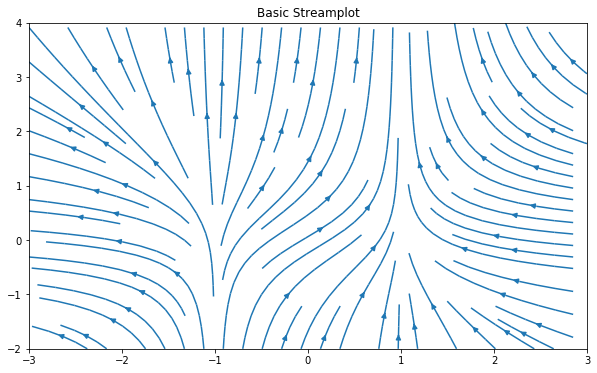

```python
plt.figure(figsize=(10,6))
plt.streamplot(X, Y, U, V)
plt.title('Basic Streamplot')
plt.show()
```

- U and V are velocity vectors as a function of x and y.A stream plot is a combination of vectors x, y and velocities U and V
- We can control the density and thickness as functions of the speed and color of the stream lines. Here is the code and its output:

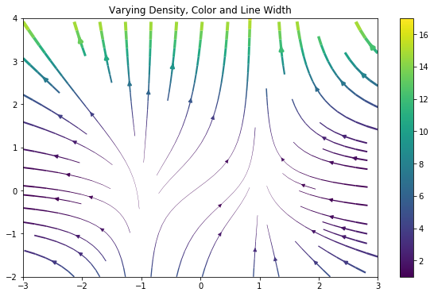

```python
# Define the speed as a function of U and V
speed = np.sqrt (U*U + V*V)
plt.figure(figsize= (10,6))

# Varying line width along a streamline
lw = 5 * speed / speed.max()

strm = plt.streamplot(X, Y, U, V, density=[0.5, 1], color=V,
                      linewidth=lw)
plt.colorbar(strm.lines)

plt.title('Varying Density, Color and Line Width')

plt.show()
```